# Payoff Intern Assessment

Justin Hilliard

May 20, 2016

# Prepare Environment

## Load ggplot and theme

```r
library("ggplot2")

jhilliard_theme <- theme(
  panel.background = element_rect(fill = "white"),
  axis.title.x = element_text(family = "Garamond", size = 14, color = "black"),
  axis.title.y = element_text(family = "Garamond", size = 14, color = "black"),
  plot.title = element_text(family = "Garamond", size = 18, color = "black"),
  legend.text = element_text(family = "Garamond", size = 10, color = "black"),
  legend.position = "right",
  legend.title = element_text(family = "Garamond", size = 12, color = "black"),
  axis.ticks = element_line(color = "black"),
  axis.text = element_text(family = "Garamond", size = 10, color = "black")
)
```

## Open DB Connection

```r
# load R Postgres Lib
library("DBI")
library("RPostgreSQL")
# Load SQL DF lib
library("sqldf")


# Establish connection to PoststgreSQL using RPostgreSQL
drv <- dbDriver("PostgreSQL")
con <- dbConnect(drv, dbname="intern",
                   host="payoff-showtime.ctranyfsb6o1.us-east-1.rds.amazonaws.com",
                   port=5432, user="payoff_intern", password="reallysecure")
```

## Sample Query And Analysis

```r
#Load Data
loan_amnt_2015 <- sqldf("select lc_15.loan_amnt, lc_15.issue_d from lending_club_2015 as lc_15", connection = con, drv = drv)
```

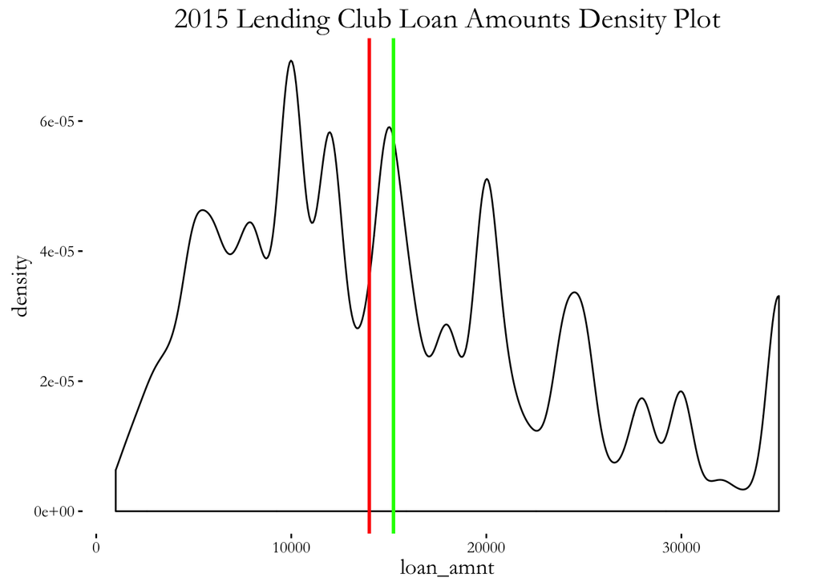

```r
# Calculate Mean and Median
loan_amnt_2015_median <- median(loan_amnt_2015$loan_amnt)
loan_amnt_2015_mean <- mean(loan_amnt_2015$loan_amnt)

# Visualize loan Amounts
ggplot(loan_amnt_2015, aes(x=loan_amnt)) + geom_density(aes(binwidth = 10000)) + jhilliard_theme + ggtitle("2015 Lending Club Loan Amounts Density Plot") + geom_vline(xintercept = loan_amnt_2015_mean, size = 1, colour = "green") + geom_vline(xintercept = loan_amnt_2015_median, size = 1, colour = "red") + jhilliard_theme
```

2015 LC Loan Amount break down

| Statistic | Value (in $) |
| --- | --- |
| Minimum | 1000 |
| 1st Quartile | 8500 |
| Median | 14000 |
| Mean | 15240 |
| 3rd Quartile | 20000 |
| Max | 35000 |

# Set A

## Monthly Total Loan Volume by Dollars and by Average Loan Size

```r
lc_07_11_avg_by_month <- sqldf("select lc_tab.issue_d as month_year, sum(lc_tab.loan_amnt), avg(lc_tab.loan_amnt) from lending_club_2007_2011 as lc_tab where lc_tab.issue_d is not null and lc_tab.loan_amnt is not null group by month_year order by to_timestamp(lc_tab.issue_d, 'Mon-YYYY') ASC", connection = con, drv = drv)

lc_12_13_avg_by_month <- sqldf("select lc_tab.issue_d as month_year, sum(lc_tab.loan_amnt), avg(lc_tab.loan_amnt) from lending_club_2012_2013 as lc_tab where lc_tab.issue_d is not null and lc_tab.loan_amnt is not null group by month_year order by to_timestamp(lc_tab.issue_d, 'Mon-YYYY') ASC", connection = con, drv = drv)

lc_14_avg_by_month <- sqldf("select lc_tab.issue_d as month_year, sum(lc_tab.loan_amnt), avg(lc_tab.loan_amnt) from lending_club_2014 as lc_tab where lc_tab.issue_d is not null and lc_tab.loan_amnt is not null group by month_year order by to_timestamp(lc_tab.issue_d, 'Mon-YYYY') ASC", connection = con, drv = drv)

lc_15_avg_by_month <- sqldf("select lc_tab.issue_d as month_year, sum(lc_tab.loan_amnt), avg(lc_tab.loan_amnt) from lending_club_2015 as lc_tab where lc_tab.issue_d is not null and lc_tab.loan_amnt is not null group by month_year order by to_timestamp(lc_tab.issue_d, 'Mon-YYYY') ASC", connection = con, drv = drv)

#bind all data vertically with Rbind
avg_summary <- rbind(lc_07_11_avg_by_month, lc_12_13_avg_by_month, lc_14_avg_by_month, lc_15_avg_by_month)
```

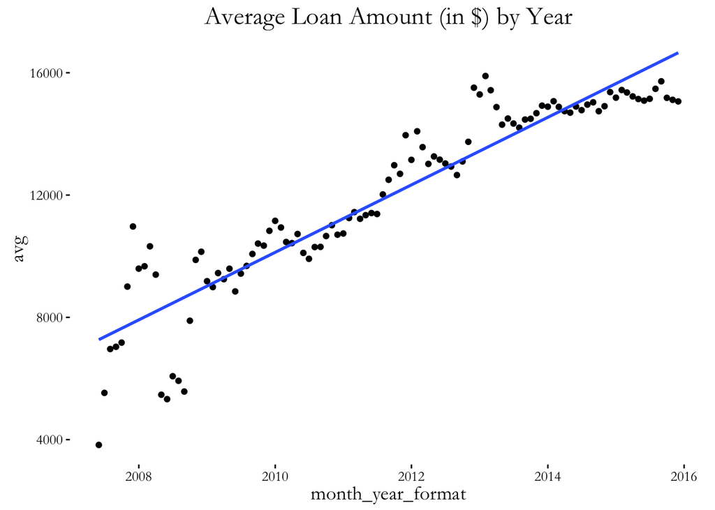

```r
library("knitr")
library("scales")

avg_summary_tab <- avg_summary

trim <- function (x) gsub("^\\s+|\\s+$", "", x)

avg_summary$month_year <- trim(avg_summary$month_year)
avg_summary$month_year_day <- paste(avg_summary$month_year,"-01", sep = "")
avg_summary$month_year_date <- as.Date(avg_summary$month_year_day, format = "%b-%Y-%d")
avg_summary$month_year_format <- as.POSIXct(avg_summary$month_year_date)

# scatter plot over time
ggplot(avg_summary, aes(x=month_year_format,y=avg)) + geom_point() + scale_x_datetime(labels = date_format("%Y")) + geom_smooth(method = "lm", se = FALSE) + ggtitle("Average Loan Amount (in $) by Year") + jhilliard_theme
```

```r
# Format Data frame with knitr
kable(avg_summary_tab, digits = 2, caption = 'Loan Amounts by Year and Month')
```

Loan Amounts by Year and Month

| month_year | sum | avg |
| --- | --- | --- |
| Jun-2007 | 91850 | 3827.08 |
| Jul-2007 | 348325 | 5528.97 |
| Aug-2007 | 515300 | 6963.51 |
| Sep-2007 | 372950 | 7036.79 |
| Oct-2007 | 753225 | 7173.57 |
| Nov-2007 | 1008650 | 9005.80 |
| Dec-2007 | 1887175 | 10971.95 |
| Jan-2008 | 2926000 | 9593.44 |
| Feb-2008 | 2959225 | 9670.67 |
| Mar-2008 | 4150050 | 10323.51 |
| Apr-2008 | 2433875 | 9397.20 |
| May-2008 | 628900 | 5468.70 |
| Jun-2008 | 660175 | 5323.99 |
| Jul-2008 | 856475 | 6074.29 |
| Aug-2008 | 592450 | 5924.50 |
| Sep-2008 | 317675 | 5573.25 |
| Oct-2008 | 962550 | 7889.75 |
| Nov-2008 | 2064900 | 9879.90 |
| Dec-2008 | 2566975 | 10146.15 |
| Jan-2009 | 2470125 | 9182.62 |
| Feb-2009 | 2714925 | 8989.82 |
| Mar-2009 | 3061300 | 9448.46 |
| Apr-2009 | 3079475 | 9247.67 |
| May-2009 | 3443300 | 9591.36 |
| Jun-2009 | 3592300 | 8848.03 |
| Jul-2009 | 3876150 | 9431.02 |
| Aug-2009 | 4318650 | 9683.07 |
| Sep-2009 | 5107225 | 10073.42 |
| Oct-2009 | 6289450 | 10413.00 |
| Nov-2009 | 6848875 | 10345.73 |

[output cut: 73 more lines]

## Default Rates by Loan Grade

```r
default_counts <- sqldf("select default_tab.grade, default_loan_amnt_bal, total_loan_amnt_bal from ( select grade,  sum(default_loan_amnt_bal) as default_loan_amnt_bal from (
select grade, tot_cur_bal as default_loan_amnt_bal from lending_club_2012_2013  as lc_tab_12_13 where lc_tab_12_13.loan_status = 'Default'
union
select grade, tot_cur_bal as default_loan_amnt_bal from lending_club_2014 as lc_tab_14 where lc_tab_14.loan_status = 'Default'
union
select grade, tot_cur_bal as default_loan_amnt_bal from lending_club_2015  as lc_tab_15 where lc_tab_15.loan_status = 'Default') as default_union
group by default_union.grade
                    ) as default_tab inner join ( select grade,  sum(total_loan_amnt_bal) as total_loan_amnt_bal from (
select grade, tot_cur_bal as total_loan_amnt_bal from lending_club_2012_2013  as lc_tab_12_13
union
select grade, tot_cur_bal as total_loan_amnt_bal from lending_club_2014 as lc_tab_14
union
select grade, tot_cur_bal as total_loan_amnt_bal from lending_club_2015  as lc_tab_15) as tot_union
group by tot_union.grade
) as total_tab on default_tab.grade = total_tab.grade", connection = con, drv = drv)

default_counts$default_percent_amnt <- (default_counts$default_loan_amnt_bal/default_counts$total_loan_amnt_bal)*100

default_counts$default_ratio_amnt <- (default_counts$default_loan_amnt_bal/default_counts$total_loan_amnt_bal)

presentation_tab <- as.data.frame(default_counts$grade)
presentation_tab$default_ratio_loan_amnt <- default_counts$default_ratio_amnt

names(presentation_tab)[names(presentation_tab) == 'default_counts$grade'] <- 'grade'

presentation_tab <- presentation_tab[order(presentation_tab$grade),]
default_counts <- default_counts[order(default_counts$grade),]

kable(presentation_tab, caption = 'Default Ratios')
```

Default Ratios

| grade | default_ratio_loan_amnt |
| --- | --- |
| A | 0.0002443 |
| B | 0.0009269 |
| C | 0.0015688 |
| D | 0.0017314 |
| E | 0.0029434 |
| F | 0.0024879 |
| G | 0.0055368 |

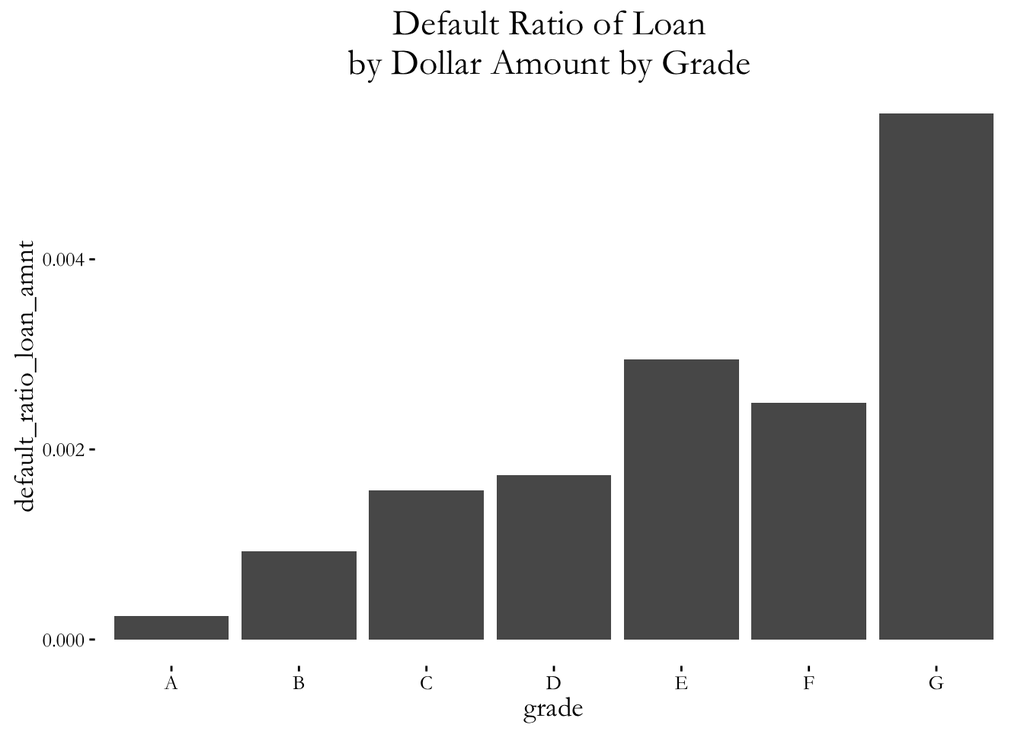

```r
ratio_dollar <- ggplot(presentation_tab, aes(x = grade, y = default_ratio_loan_amnt)) + geom_bar( position = "dodge", stat = "identity") + ggtitle("Default Ratio of Loan \nby Dollar Amount by Grade ") + jhilliard_theme

ratio_dollar
```

## Adjusting for Risk

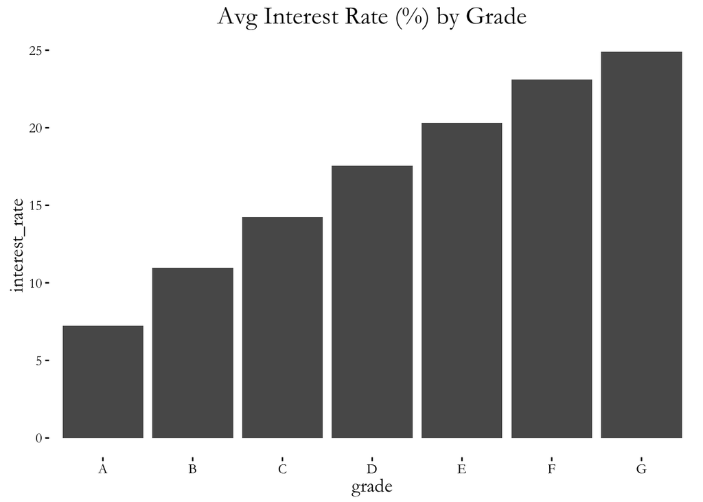

```r
interest_rates <- sqldf("select grade, avg(int_rate) as interest_rate from (
select grade, cast(trim(trailing '%' from trim(both ' ' from int_rate)) as double precision)  as int_rate  from lending_club_2012_2013
union
select grade, cast(trim(trailing '%' from trim(both ' ' from int_rate)) as double precision)  as int_rate  from lending_club_2014
union
select grade, int_rate from lending_club_2015) as tot_union
group by tot_union.grade", connection = con, drv = drv)

chargeoff_rates <- sqldf("select grade,  sum(default_loan_amnt_bal) as chargeoff_loan_amnt_bal from (
 select grade, tot_cur_bal as default_loan_amnt_bal from lending_club_2012_2013  as lc_tab_12_13 where lc_tab_12_13.loan_status = 'Charged Off'
 union
 select grade, tot_cur_bal as default_loan_amnt_bal from lending_club_2014 as lc_tab_14 where lc_tab_14.loan_status = 'Charged Off'
 union
 select grade, tot_cur_bal as default_loan_amnt_bal from lending_club_2015  as lc_tab_15 where lc_tab_15.loan_status = 'Charged Off') as default_union
 group by default_union.grade", connection = con, drv = drv)

chargeoff_rates <- chargeoff_rates[order(chargeoff_rates$grade),]

ggplot(interest_rates, aes(x = grade, y = interest_rate)) + geom_bar( position = "dodge", stat = "identity") + ggtitle("Avg Interest Rate (%) by Grade") + jhilliard_theme
```

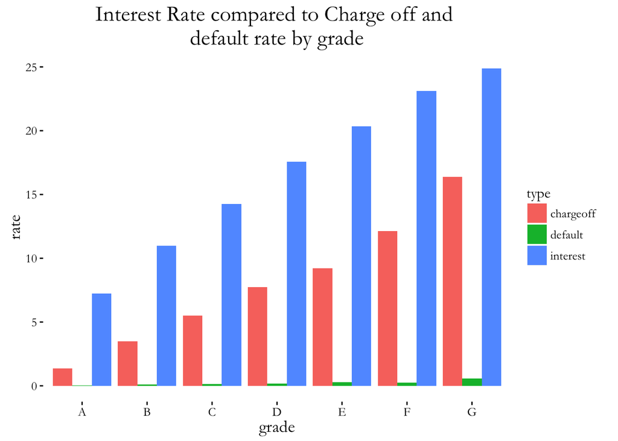

```r
charging_enough <- merge(interest_rates, default_counts, by = "grade")
charging_enough <- merge(chargeoff_rates, charging_enough, by = "grade")

charging_enough$default_percent_amnt <- NULL
charging_enough$chargeoff_ratio_amnt <- (charging_enough$chargeoff_loan_amnt_bal/charging_enough$total_loan_amnt_bal)

interest_bind <- interest_rates
interest_bind$type <- "interest"
interest_bind$rate <- interest_rates$interest_rate
interest_bind$interest_rate <- NULL

chargeoff_bind <- chargeoff_rates
chargeoff_bind$chargeoff_loan_amnt_bal <- NULL
chargeoff_bind$type <- "chargeoff"
chargeoff_bind$rate <- charging_enough$chargeoff_ratio_amnt*100

default_bind <- chargeoff_rates
default_bind$chargeoff_loan_amnt_bal <- NULL
default_bind$type <- "default"
default_bind$rate <- charging_enough$default_ratio_amnt*100

stackedChart <- rbind(default_bind, chargeoff_bind, interest_bind)

ggplot(stackedChart, aes(x = grade, y = rate, fill=type)) + geom_bar( position = "dodge", stat = "identity") + ggtitle("Interest Rate compared to Charge off and \ndefault rate by grade") + jhilliard_theme
```

```r
interest_bind$type <- NULL
names(interest_bind)[names(interest_bind) == 'rate'] <- 'interest_rate'

chargeoff_bind$type <- NULL
names(chargeoff_bind)[names(chargeoff_bind) == 'rate'] <- 'chargeoff_rate'

default_bind$type <- NULL
names(default_bind)[names(default_bind) == 'rate'] <- 'default_rate'

rate_tab <- merge(default_bind, chargeoff_bind, by = "grade")
rate_tab <- merge(rate_tab, interest_bind, by = "grade")

kable(rate_tab)
```

| grade | default_rate | chargeoff_rate | interest_rate |
| --- | --- | --- | --- |
| A | 0.0244327 | 1.363471 | 7.229259 |
| B | 0.0926853 | 3.485471 | 10.986047 |
| C | 0.1568814 | 5.505939 | 14.251633 |
| D | 0.1731403 | 7.732144 | 17.558684 |
| E | 0.2943373 | 9.203084 | 20.327955 |
| F | 0.2487901 | 12.142074 | 23.112727 |
| G | 0.5536756 | 16.384684 | 24.889231 |

Assuming the operational costs are lower than the difference of charge-off rates + default rates seems like we are charging a appropriate interest rate for risk.

## Predictors

Using the correlation method with dummy coding we can see which variable best predict loans that have gone into default or are charged off.

```r
predictor <- sqldf("Select annual_inc,
annual_inc_joint,
application_type,
bc_util,
chargeoff_within_12_mths,
collections_12_mths_ex_med,
delinq_2yrs,
dti,
dti_joint,
grade,
il_util,
int_rate,
loan_status,
mths_since_last_delinq,
mths_since_recent_bc_dlq,
num_accts_ever_120_pd,
num_actv_bc_tl,
num_actv_rev_tl,
num_bc_sats,
num_bc_tl,
num_il_tl,
num_op_rev_tl,
num_rev_accts,
num_tl_120dpd_2m,
num_tl_30dpd,
num_tl_90g_dpd_24m,
open_acc,
pub_rec,
pub_rec_bankruptcies,
total_acc
from lending_club_2015", connection = con, drv = drv)

predictor$is_charge_off <- ifelse(predictor$loan_status == "Charged Off", "chargeoff_default", ifelse(predictor$loan_status == "Default","chargeoff_default","normal"))

con_grade_charge <- table(predictor$grade, predictor$is_charge_off)

kable(con_grade_charge)
```

|  | chargeoff_default | normal |
| --- | --- | --- |
| A | 214 | 73122 |
| B | 854 | 116752 |
| C | 1726 | 118841 |
| D | 1694 | 60960 |
| E | 1274 | 33674 |
| F | 582 | 9235 |
| G | 170 | 1997 |

```r
chisq.test(con_grade_charge)
```

```
##
##  Pearson's Chi-squared test
##
## data:  con_grade_charge
## X-squared = 4652.2, df = 6, p-value < 2.2e-16
```

Because of the extremely small p value we can conclude that grade and charge-off rate are not independent

```r
predictor$is_charge_off <- ifelse(predictor$loan_status == "Charged Off", 1, ifelse(predictor$loan_status == "Default",1,0))

predictor$grade_num <- ifelse(predictor$grade == "A", 6, ifelse(predictor$grade == "B",5,  ifelse(predictor$grade == "C",4, ifelse(predictor$grade == "D",3, ifelse(predictor$grade == "E",2, ifelse(predictor$grade == "F",1,  ifelse(predictor$grade == "G",0,0)))))))

predictor$loan_status <- NULL
predictor$grade <- NULL

predictor$annual_inc_joint <- ifelse(predictor$annual_inc_joint %in% NA, predictor$annual_inc, predictor$annual_inc_joint)
predictor$dti_joint <- ifelse(predictor$dti_joint %in% NA, predictor$dti, predictor$dti_joint)
predictor$mths_since_last_delinq <- ifelse(predictor$mths_since_last_delinq %in% NA, -1, predictor$mths_since_last_delinq)
predictor$mths_since_recent_bc_dlq <- ifelse(predictor$mths_since_recent_bc_dlq %in% NA, -1, predictor$mths_since_recent_bc_dlq)
predictor$application_type <- ifelse(predictor$application_type %in% "INDIVIDUAL", 0, 1)
predictor$il_util <- NULL

correlation_predictors <- as.data.frame(cor(predictor, use="complete.obs", method="pearson"))

correlation_tab <- data.frame(c("annual_inc",
"annual_inc_joint",
"application_type",
"bc_util",
"chargeoff_within_12_mths",
"collections_12_mths_ex_med",
"delinq_2yrs",
"dti",
"dti_joint",
"int_rate",
"mths_since_last_delinq",
"mths_since_recent_bc_dlq",
"num_accts_ever_120_pd",
"num_actv_bc_tl",
"num_actv_rev_tl",
"num_bc_sats",
"num_bc_tl",
"num_il_tl",
"num_op_rev_tl",
"num_rev_accts",
"num_tl_120dpd_2m",
"num_tl_30dpd",
"num_tl_90g_dpd_24m",
"open_acc",
"pub_rec",
"pub_rec_bankruptcies",
"total_acc",
"is_charge_off",
"grade_num"))
colnames(correlation_tab)[1] <- "var_names"

correlation_tab$charge_off_correlation_for_predictors <- correlation_predictors$is_charge_off

kable(correlation_tab)
```

| var_names | charge_off_correlation_for_predictors |
| --- | --- |
| annual_inc | -0.0113354 |
| annual_inc_joint | -0.0114416 |
| application_type | -0.0044712 |
| bc_util | 0.0143721 |
| chargeoff_within_12_mths | 0.0027518 |
| collections_12_mths_ex_med | 0.0047520 |
| delinq_2yrs | 0.0014083 |
| dti | 0.0104348 |
| dti_joint | 0.0300229 |
| int_rate | 0.1061682 |
| mths_since_last_delinq | -0.0048548 |
| mths_since_recent_bc_dlq | 0.0008268 |
| num_accts_ever_120_pd | 0.0000411 |
| num_actv_bc_tl | -0.0050306 |
| num_actv_rev_tl | -0.0007491 |
| num_bc_sats | -0.0068038 |
| num_bc_tl | -0.0032284 |
| num_il_tl | 0.0014479 |
| num_op_rev_tl | -0.0040660 |
| num_rev_accts | -0.0033899 |
| num_tl_120dpd_2m | 0.0015023 |
| num_tl_30dpd | 0.0013272 |
| num_tl_90g_dpd_24m | 0.0030947 |
| open_acc | -0.0045601 |
| pub_rec | 0.0027876 |
| pub_rec_bankruptcies | 0.0027841 |
| total_acc | -0.0046941 |
| is_charge_off | 1.0000000 |
| grade_num | -0.1018479 |

That said, within the subset of continuous variables used to determine predictors by correlation on whether a loan was defaulted or charged off, there does not seem to be any variables in this subset that very strongly correlate with a loan being charged off or in default.

**Interest rate and Grade have the largest correlation to loans being charged off or in default, but it is still not a great predictor.**

# Set B

## Data Errors

1. The data is inconsistent across the year tables (ie., data types). I would not have structured the data like this I probably would have broken the data down into tables that were more dependent on field type optimizing for 3NF. There also seems to be fields missing across years (ie., Fico scores do not exist for 2015 table)
2. I would have made the free-form data exclusivley categorical dropdowns. It is difficult to analyze data when it is not standardized. For example, look at the title field that was pulled from the lending_club_2007_2011 table.

**Title**

1. Computer
2. bike
3. real estate business
4. personel
5. Personal
6. My wedding loan I promise to pay back
- “My wedding loan I promise to pay back” while comical is not helpful as an analyst. Also misspelled words, such as “personel”, are not helpful.

## Concept Explination

### K-means Clustering

#### Math Background

- K-means clustering is an unsupervised learning algorithm where we aim to minimize the squared-error of data points from a variable number of centroids. This is done to cluster data points together and classify new data points. We iterate over the data then readjust the centroids until the centroids are optimally minimizing the squared-error. This is typically known as a greedy algorithm.

#### Non-Math Background

- This is a machine learning algorithm that we can use to classify data points to determine which points are most similar to one another. The data points are clustered into a variable number of clusters determined by the analyst. For example, let’s say we had a data set with 200 data points, 100 of which measure the surface area of 100 Bananas, 100 of which measure the surface area of 100 Apples. We can use K-means clustering algorithm with the input of 2 clusters to determine which data points are Bananas and which data points are Apples.